# HETH_popAssignment_7-21-2021

Nicole Adams

7/21/2021

# HETH Population Assignment

Since there is population structure within HETH, we have to assign each of our individuals to a genetic region.

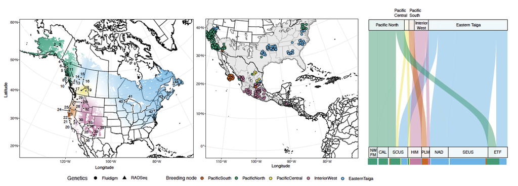

HETH genoscape (Alvarado)

# Process Teresa’s HETH samples

The HETH genoscape has a sample gap in the upper Midwest and central Canada. Luckily, Teresa Pegan from Ben Winger’s lab has genomes from HETH collected in that area. Teresa generously shared her .fastq files (N=38) with me via Globus file transfer for our pop assignment analysis. Teresa also sent me a metadata file for the samples (Sequencing_metadata_for_Nicole.csv). Teresa said two samples failed the sequencing, UP17003 and MB19010 and not to use them in the analysis.

On Xsede, move files out of individual directories:

```bash
cp /ocean/projects/deb200006p/adamsne2/HETH/teresaPegan_files/*/*.gz /ocean/projects/deb200006p/adamsne2/HETH/teresaPegan_files/

# rm fastq files from w/in directories
rm */*.fq.gz
```

## Trim fastqs

Remove any adapters and trim raw reads based on read length and quality using Trim Galore!

Trimming sbatch file (~/scripts/trimgalore_HETH.sbatch)

```bash
#!/bin/bash
#SBATCH --job-name=TRIM
#SBATCH --output=TRIM.%j.out
#SBATCH --error=TRIM.%j.err
#SBATCH -t 48:00:00
#SBATCH -p RM-shared
##SBATCH -N 1
##SBATCH --mem=128G
#SBATCH -A
#SBATCH --mail-type=END
#SBATCH  --mail-user=

set -x

module load FastQC/0.11.9
module load cutadapt/2.10
module load python/3.8.6

###Identify directories
#fastq="/ocean/projects/deb200006p/adamsne2/HETH/raw_data/usftp21.novogene.com/raw_data"
fastq="/ocean/projects/deb200006p/adamsne2/HETH/teresaPegan_files"
num=$2
sample=$1

#Note: Take a look at the names of the sample files and adjust this loop accordingly
#For example, mine all had "CKDL190142674-1a-AK12626-AK16295_H3VF5CCX2_L8_2.fq.gz" or "USPD16094205-N707-AK392_HY5K5CCXY_L7_2.fq.gz" tacked on.

### Trim low quality fragments and Illumina TruSeq adapters (-q = quality, --cores 1-4 python3 uses 2)
#mkdir ../trimd
#cd ../trimd

# leave adapters blank so uses the auto-detect
# My HETH samples
#/jet/home/adamsne2/programs/TrimGalore-0.6.5/trim_galore -q 15 --paired --fastqc \
#$fastq/$sample\_L3_1.fq.gz $fastq/$sample\_L3_2.fq.gz

# for teresa's files for HETH assignment
/jet/home/adamsne2/programs/TrimGalore-0.6.5/trim_galore -q 15 --paired --fastqc \
$fastq/$sample\_L1_1.fq.gz $fastq/$sample\_L1_2.fq.gz
```

Trim all samples by lane (L1, L2)

```bash
for sample in `ls *_L1_1.fq.gz | cut -f1,2,3 -d '_'`; do echo $sample; sbatch ~/scripts/trimgalore_HETH.sbatch $sample; done

for sample in `ls *_L2_1.fq.gz | cut -f1,2,3 -d '_'`; do echo $sample; sbatch ~/scripts/trimgalore_HETH2.sbatch $sample; done
```

## Mapping

Use bwa mem (included -M parameter for compatibility with picard)

Mapping sbatch file (~/scripts/map.bwa_HETH.teresa.sbatch)

```bash
#!/bin/bash
#SBATCH --job-name=map_bwa
#SBATCH --output=map-bwa.%j.out
#SBATCH --error=map-bwa.%j.err
#SBATCH -t 48:00:00
#SBATCH -p EM
##SBATCH -N 1
#SBATCH --ntasks-per-node 24
##SBATCH --mem=128G
#SBATCH -A
#SBATCH --mail-type=END
#SBATCH  --mail-user=

set -x


module load BWA/0.7.3a
module load samtools/1.11.0
module load picard/2.23.2

##Variables: Plate number and directory for bamUtil
PLATE="teresa"
BAMUTIL="/jet/home/adamsne2/programs/bamUtil/bin"
REFERENCE="/ocean/projects/deb200006p/adamsne2/HETH/reference/HETH.rmcont.assembly.fasta"
lane=$2
sample=$1
sample2=$3


cd /ocean/projects/deb200006p/adamsne2/HETH/teresaPegan_files/

##Align each sample to genome. Note that genome reference must already be built through bwa
#mkdir ../../../bwa_map

ID="$PLATE.$sample2.$lane"

##map trimmed reads BY lane
bwa mem -t 20 -M $REFERENCE "$sample"_1_val_1.fq.gz "$sample"_2_val_2.fq.gz > /ocean/projects/deb200006p/adamsne2/HETH/bwa_map/"$sample2".sam

cd /ocean/projects/deb200006p/adamsne2/HETH/bwa_map/

#########sort, add read group information and index it#########
samtools sort -o "$sample2".bam "$sample2".sam -@ 10
samtools index "$sample2".bam -@10

##Add read groups
java -jar /jet/home/adamsne2/programs/picard.jar AddOrReplaceReadGroups INPUT="$sample2".bam RGID="$ID" RGLB="$PLATE" RGPL=illumina RGPU="$PLATE"."$sample2"."lane" RGSM="$sample2" OUTPUT="$sample2"_RG.bam VALIDATION_STRINGENCY=SILENT

samtools index "$sample2"_RG.bam -@10


rm "$sample2".sam
```

Map loop for all samples by lane (L1, L2)

```bash
for sample in `ls *L1_1_val_1.fq.gz | cut -f1,2,3,4 -d'_'`; do lane=`ls $sample\_1_val_1.fq.gz | cut -f4 -d"_"`; sample2=`ls $sample\_1_val_1.fq.gz | cut -f1 -d'_'`; echo $sample; echo $lane;echo $sample2; sbatch ~/scripts/map.bwa_HETH.teresa.sbatch $sample $lane $sample2; done

for sample in `ls *L2_1_val_1.fq.gz | cut -f1,2,3,4 -d'_'`; do lane=`ls $sample\_1_val_1.fq.gz | cut -f4 -d"_"`; sample2=`ls $sample\_1_val_1.fq.gz | cut -f1 -d'_'`; echo $sample; echo $lane;echo $sample2; sbatch ~/scripts/map.bwa_HETH.teresa.sbatch $sample $lane $sample2; done
```

Mapping summaries Bash commands for samtools flagstat to get mapping summaries. Then take the results and make a table and combine into one file to be put into Rstudio.

batch file (~/scripts/sam.flagstat_HETH.teresa.sbatch)

```bash
#!/bin/bash
#SBATCH --job-name=map_sum
#SBATCH --output=map-sum.%j.out
#SBATCH --error=map-sum.%j.err
#SBATCH -t 24:00:00
#SBATCH -p RM-shared
##SBATCH -N 1
##SBATCH --ntasks-per-node 24
##SBATCH --mem=128G
#SBATCH -A
#SBATCH --mail-type=END
#SBATCH  --mail-user=

set -x


module load samtools/1.11.0

#cd /ocean/projects/deb200006p/adamsne2/HETH/bwa_map

touch mapSummary_HETH_teresa.txt

for sample in `ls *_RG.bam | cut -f1 -d'.'`
do
  samtools flagstat "$sample".bam -@ 10  > "$sample"_mapSum.txt
 awk 'FNR == 1{ print FILENAME }' "$sample"_mapSum.txt >> mapSummary_HETH_teresa.txt
 cat "$sample"_mapSum.txt >> mapSummary_HETH_teresa.txt

done

for sample in *mapSum.txt; do awk 'FNR == 1{ print FILENAME } {printf "%-20s %-40s\n", $1, $3}' OFS="\t" $sample | awk '
{
    for (i=1; i<=NF; i++)  {
        a[NR,i] = $i
    }
}
NF>p { p = NF }
END {
    for(j=1; j<=p; j++) {
        str=a[1,j]
        for(i=2; i<=NR; i++){
            str=str" "a[i,j];
        }
        print str
    }
}' >> mapSummary_HETH_teresa.2.txt; done

rm *_mapSum.txt
```

scp map summary file to computer and do one more formatting step

```bash
grep '[[:alpha:]]' mapSummary_HETH_teresa.2.txt > mapSummary_HETH_teresa.3.txt
```

Load in R libraries

```r
library(readxl)
library(data.table)
library(tidyverse)
library(viridis)
library(cowplot)
library(ggpubr)
library(knitr)
library(kableExtra)
library(RColorBrewer)
library(scales)
```

Load in Teresa’s metadata

```r
meta.t <- read.csv("~/Documents/clim_morph_HETH/teresaPegan_HETHfiles/Sequencing_metadata_for_Nicole.csv")

meta.t <- meta.t %>% dplyr::select(-X)

meta.t$Sample <- meta.t$Novogene_Sample_Name

meta.t$Long <- meta.t$Lon
```

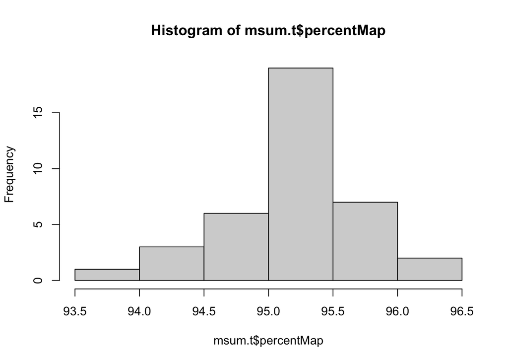

```r
msum.t <- read.table("~/Documents/clim_morph_HETH/mapSummary_HETH_teresa.3.txt")

colnames(msum.t) <- c("Sample", "QCpassedReads", "secondary", "supplementary", "duplicates", "mapped", "paired", "read1", "read2", "properlyPaired", "itselfYmateMapped", "singletons", "mateMappedDiffChr", "mateMappedDiffChr_mapQ5")

msum.t <- msum.t %>% separate(Sample, c("Sample", "rg", "stuff", "file")) %>% dplyr::select(-rg, -stuff, -file)

msum.t$percentMap <- (msum.t$mapped/msum.t$QCpassedReads)*100
msum.t$percentPaired <- (msum.t$properlyPaired/msum.t$paired)*100
msum.t$percentSingle <- (msum.t$singletons/msum.t$properlyPaired)*100

# merge mapping summary with meta data
meta.t2 <- inner_join(meta.t, msum.t)


hist(msum.t$percentMap)
```

Average mapping is 95.2% (85.7% for proper pairs), which is lower than the HETH samples for GWAS…

## Mark Duplicates

sbatch file (~/scripts/markdups_HETH.sbatch)

```bash
#!/bin/bash
#SBATCH --job-name=mrkdup
#SBATCH --output=mrkdup.%j.out
#SBATCH --error=mrkdup.%j.err
#SBATCH -t 48:00:00
#SBATCH -p EM
##SBATCH -N 1
#SBATCH --ntasks-per-node 24
##SBATCH --mem=128G
#SBATCH -A
#SBATCH --mail-type=END
#SBATCH  --mail-user=


set -x

sample=$1
sample2=$2

module load samtools/1.11.0
module load GATK/4.1.9.0

#cd /ocean/projects/deb200006p/adamsne2/HETH/bwa_map

java -jar /jet/home/adamsne2/programs/picard.jar MarkDuplicates \
      I="$sample" \
      O="$sample2".mrkdup.bam \
      M="$sample2".mrkdup_metrics.txt

samtools index "$sample2".mrkdup.bam
```

loop to submit mark duplicates

```bash
for sample in `ls *_RG.bam`; do sample2=`ls $sample | cut -f1 -d'.'| cut -f1,2 -d"_"`; echo $sample; echo $sample2; sbatch ~/scripts/markdups_HETH.sbatch $sample $sample2; done
```

Combine markdup metrics Bash code to combine markdup metric summaries

```bash
touch HETH_teresa_mrkdup_metrics.txt

for sample in *RG.mrkdup_metrics.txt; do grep "^teresa" $sample /dev/null >> HETH_teresa_mrkdup_metrics.txt; done
```

scp file to laptop then put combined metric summary into Rstudio

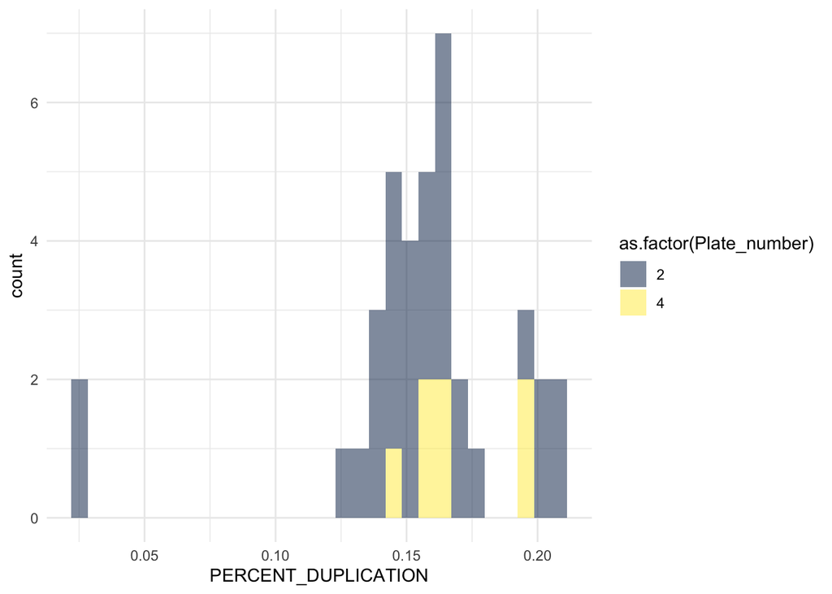

```r
# Data input and wrangling
dups.t <- as.data.frame(read_tsv("/Users/neasci/Documents/clim_morph_HETH/HETH_teresa_mrkdup_metrics.txt", col_names = FALSE))

colnames(dups.t) <- c("LIBRARY", "UNPAIRED_READS_EXAMINED", "READ_PAIRS_EXAMINED", "SECONDARY_OR_SUPPLEMENTARY_RDS", "UNMAPPED_READS", "UNPAIRED_READ_DUPLICATES", "READ_PAIR_DUPLICATES", "READ_PAIR_OPTICAL_DUPLICATES", "PERCENT_DUPLICATION", "ESTIMATED_LIBRARY_SIZE")

 dups.t <- dups.t %>% separate(LIBRARY, c("Sample", "stuff1", "stuff2", "stuff3", "file", "library1")) %>% subset(select=-c(stuff1, stuff2, stuff3, file, library1))

 # combine with metadata
 meta.t3 <- inner_join(meta.t2, dups.t)

 p.dups.t <- ggplot(meta.t3, aes(x=PERCENT_DUPLICATION, fill=as.factor(Plate_number))) +
  geom_histogram( alpha=0.5, show.legend = T) +
  scale_fill_viridis(discrete = T, option = "cividis") +
  theme_minimal()

 p.dups.t2 <- ggplot(meta.t3, aes(x= percentMap, y=PERCENT_DUPLICATION, color=as.factor(Plate_number))) +
   geom_point() +
   scale_color_viridis(discrete = T, option = "cividis") +
  theme_minimal()

 p.dups.t
```

## Estimate depth of coverage with Picard collect wgs

Batch script to calculate coverage using Picard (collectWGSmetrics_HETH.sbatch)

```bash
#!/bin/bash
#SBATCH --job-name=wgsMetrics
#SBATCH --output=wgs.%j.out
#SBATCH --error=wgs.%j.err
#SBATCH -t 48:00:00
#SBATCH -p EM
##SBATCH -N 1
#SBATCH --ntasks 24
##SBATCH --mem=120G
#SBATCH -A
#SBATCH --mail-type=END
#SBATCH  --mail-user=

set -x


module load GATK/4.1.9.0

RGbam=$1
sample=$2
sampleRG=$3

REFERENCE="/ocean/projects/deb200006p/adamsne2/HETH/reference/HETH.rmcont.assembly.fasta"

cd /ocean/projects/deb200006p/adamsne2/HETH/bwa_map

java -jar /jet/home/adamsne2/programs/picard.jar CollectWgsMetrics\
      I="$sampleRG".mrkdup.bam \
      O="$sample".collectWGSmetrics.txt \
      R=$REFERENCE


#touch HETH_005-6.collectWGSmetrics.txt
#for sample in *collectWGSmetrics.txt; do awk 'FNR == 1 {print FILENAME}  FNR == 8 {print}' $sample >> HETH_005-6.collectWGSmetrics.txt; done
```

loop to get coverage

```bash
for RGbam in *RG.bam ; do sample=`ls $RGbam | cut -f1 -d'.'| cut -f1 -d'_'`;  sampleRG=`ls $RGbam | cut -f1 -d'.'`; echo $RGbam $sample $sampleRG; sbatch ~/scripts/collectWGSmetrics_HETH.teresa.sbatch $RGbam $sample $sampleRG; done
```

Combine collectWGS metrics Bash code to combine collectWGS metric summaries. code from (here)[https://stackoverflow.com/questions/42941329/how-can-i-print-the-nth-5th-line-of-every-file-preceded-by-the-filename-using]

```bash
touch HETH_teresa.collectWGSmetrics.txt

for file in *_RG.bam; do sample=`ls $file | cut -f1 -d'.'| cut -f1 -d"_"`; echo "$sample".collectWGSmetrics.txt $(sed 's/ /,/;s/$/,/;8q;d' "$sample".collectWGSmetrics.txt) >> HETH_teresa.collectWGSmetrics.txt; done
```

scp file to laptop

Put combined collect metrics into R

```r
wgs.t <- as.data.frame(read_tsv("/Users/neasci/Documents/clim_morph_HETH/HETH_teresa.collectWGSmetrics.txt", col_names = FALSE))

wgs.t2 <- wgs.t %>% separate(X1, c("Sample", "GENOME_TERRITORY", "MEAN_COVERAGE", "SD_COVERAGE", "MEDIAN_COVERAGE", "MAD_COVERAGE", "PCT_EXC_ADAPTER", "PCT_EXC_MAPQ", "PCT_EXC_DUPE", "PCT_EXC_UNPAIRED", "PCT_EXC_BASEQ", "PCT_EXC_OVERLAP", "PCT_EXC_CAPPED", "PCT_EXC_TOTAL", "PCT_1X", "PCT_5X", "PCT_10X", "PCT_15X", "PCT_20X", "PCT_25X", "PCT_30X", "PCT_40X", "PCT_50X", "PCT_60X", "PCT_70X", "PCT_80X", "PCT_90X", "PCT_100X", "HET_SNP_SENSITIVITY", "HET_SNP_Q"), sep = '\\s')

# remove file name and keep sample name
wgs.t3 <- wgs.t2 %>% separate(Sample, c("Sample", "stuff1", "stuff2")) %>% dplyr::select(-stuff1, -stuff2)

# merge with meta data
 meta.t4 <- inner_join(meta.t3, wgs.t3)

# convert character columns to numeric
cols.num <- c("GENOME_TERRITORY", "MEAN_COVERAGE", "SD_COVERAGE", "MEDIAN_COVERAGE", "MAD_COVERAGE", "PCT_EXC_ADAPTER", "PCT_EXC_MAPQ", "PCT_EXC_DUPE", "PCT_EXC_UNPAIRED", "PCT_EXC_BASEQ", "PCT_EXC_OVERLAP", "PCT_EXC_CAPPED", "PCT_EXC_TOTAL", "PCT_1X", "PCT_5X", "PCT_10X", "PCT_15X", "PCT_20X", "PCT_25X", "PCT_30X", "PCT_40X", "PCT_50X", "PCT_60X", "PCT_70X", "PCT_80X", "PCT_90X", "PCT_100X", "HET_SNP_SENSITIVITY")

meta.t4[cols.num] <- sapply(meta.t4[cols.num],as.numeric)

wgs.t.tab <- t(as.data.frame(c(length(meta.t4$Sample), mean(meta.t4$MEAN_COVERAGE), mean(meta.t4$PCT_5X))))
colnames(wgs.t.tab) <- c("Samples", "Avg_meanCov", "Avg_pct5X")
rownames(wgs.t.tab) <- c("HETH_teresa")
wgs.t.tab2 <- as.data.frame(wgs.t.tab)

wgs.t.tab2
```

```
##             Samples Avg_meanCov Avg_pct5X
## HETH_teresa      38    2.541492 0.1517239
```

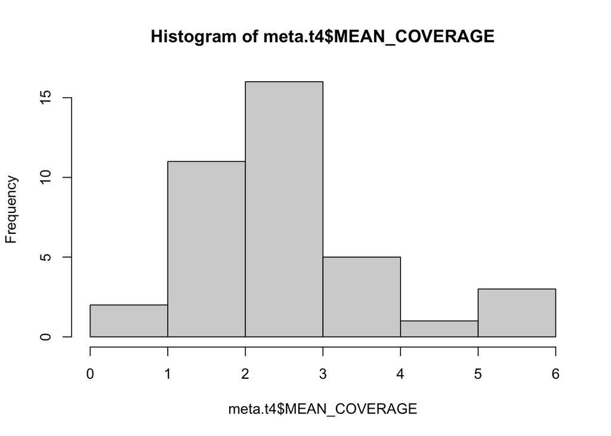

```r
hist(meta.t4$MEAN_COVERAGE)
```

Average coverage is 2.5x, which is also lower than the other HETH samples for GWAS, but not by much…

Identify low coverage samples

```r
low.cov.t <- meta.t4 %>% filter(MEAN_COVERAGE < 2) %>% arrange(MEAN_COVERAGE)

low.cov.t %>% dplyr::select(Sample, MEAN_COVERAGE, percentMap, PERCENT_DUPLICATION) %>% arrange(MEAN_COVERAGE)
```

```
##     Sample MEAN_COVERAGE percentMap PERCENT_DUPLICATION
## 1  UP17003      0.005455   94.71939            0.027958
## 2  MB19010      0.007552   95.01387            0.026963
## 3  UP17108      1.611216   93.83524            0.201526
## 4  MB19160      1.654793   95.41803            0.152857
## 5  MB19196      1.695670   95.23664            0.141268
## 6   C72442      1.751523   95.63583            0.150964
## 7  MB19253      1.810712   95.38802            0.141456
## 8  MB19280      1.837616   95.30369            0.134429
## 9   C72443      1.892483   95.34467            0.142550
## 10 MB19222      1.918839   95.61277            0.135919
## 11 UP18058      1.927172   95.46537            0.143373
## 12 MB19250      1.959847   95.79384            0.207625
## 13 MN17085      1.980682   96.41558            0.209883
```

The two previously identified failed samples (UP17003, MB19010) have the lowest coverage (< 0.01x). The other low cov samples range from 1.6-1.9x.

# Call SNPs for population assignment

## Identify SNPs

We are calling SNPs using the Ruegg lab RADseq sites for HETH to assign individuals.

Downloaded the RAD sites VCF file from the Bird Genoscape Google Drive BGP_Data_Share/Large_SNP_files/HETH/HETH.all.clean.hethv0.rm_hets.rmrel.rmcont.vcf and put it in the HETH reference directory /ocean/projects/deb200006p/adamsne2/HETH/reference/

Count the number of SNPs in the RADseq VCF

```bash
grep -v "#" HETH.all.clean.hethv0.rm_hets.rmrel.rmcont.vcf |wc -l
```

90,439 SNPs

The RAD sites VCF file had the prefix “scaf_” for every scaffold. I removed that so it would match the bam files, which didn’t have any prefix

```bash
# remove 'scaf_' and create new file
awk '{gsub(/scaf_/,""); print}' HETH.all.clean.hethv0.rm_hets.rmrel.rmcont.vcf > HETH.all.clean.hethv0.rm_hets.rmrel.rmcont_rmscaf.vcf

# compress (bgzip) and index (tabix) new VCF for downstream compatability
~/programs/ngsTools/htslib/bgzip -c -@ 10 HETH.all.clean.hethv0.rm_hets.rmrel.rmcont_rmscaf.vcf > HETH.all.clean.hethv0.rm_hets.rmrel.rmcont_rmscaf.vcf.gz

~/programs/ngsTools/htslib/tabix HETH.all.clean.hethv0.rm_hets.rmrel.rmcont_rmscaf.vcf.gz
```

## Call variants with bcftools

I originally tried to call SNPs with GATK but it ended up taking forever so I switched to bcftools, but before that I added read groups to the bams. GATK requires bams to have unique read groups, so I had to add read groups to our HETH bams, I already included it in Teresa’s HETHs.

I used the original HETH mapping script so it gets all the file info and just comment out all the other steps besides the add read groups then added mrkdups to the name because I had already marked the duplicates

Modified batch script to add read groups (~/scripts/map.bwa_HETH.mrkdup.sbatch)

```bash
#!/bin/bash
#SBATCH --job-name=map_bwa
#SBATCH --output=map-bwa.%j.out
#SBATCH --error=map-bwa.%j.err
#SBATCH -t 48:00:00
#SBATCH -p RM-shared
##SBATCH -N 1
##SBATCH --ntasks-per-node 24
##SBATCH --mem=128G
#SBATCH -A
#SBATCH --mail-type=END
#SBATCH  --mail-user=

set -x


module load BWA/0.7.3a
module load samtools/1.11.0
module load picard/2.23.2

##Variables: Plate number and directory for bamUtil
PLATE="HETH_006"
BAMUTIL="/jet/home/adamsne2/programs/bamUtil/bin"
REFERENCE="/ocean/projects/deb200006p/adamsne2/HETH/reference/HETH.rmcont.assembly.fasta"
lane=$2
sample=$1
sample2=$3


#cd /ocean/projects/deb200006p/adamsne2/HETH/raw_data/usftp21.novogene.com/trimd/

##Align each sample to genome. Note that genome reference must already be built through bwa
#mkdir ../../../bwa_map

ID="$PLATE.$sample2.$lane"

##map trimmed reads BY lane
#bwa mem -t 20 -M $REFERENCE "$sample"_1_val_1.fq.gz "$sample"_2_val_2.fq.gz > /ocean/projects/deb200006p/adamsne2/HETH/bwa_map/"$sample2".sam

cd /ocean/projects/deb200006p/adamsne2/HETH/bwa_map/

#########sort, add read group information and index it#########
#samtools sort -o "$sample2".bam "$sample2".sam -@ 10
#samtools index "$sample2".bam -@10

##Add read groups (dont do this for HETH)
java -jar /jet/home/adamsne2/programs/picard.jar AddOrReplaceReadGroups INPUT="$sample2".mrkdup.bam RGID="$ID" RGLB="$PLATE" RGPL=illumina RGPU="$PLATE"."$sample2"."lane" RGSM="$sample2" OUTPUT="$sample2"_RG.mrkdup.bam VALIDATION_STRINGENCY=SILENT

samtools index "$sample2"_RG.mrkdup.bam -@10


#rm "$sample2".sam
```

Loop to add read groups by lane (L3=HETH_005, L4=HETH_006)

```bash
for sample in `ls *L3_1_val_1.fq.gz | cut -f1,2,3,4 -d'_'`; do lane=`ls $sample\_1_val_1.fq.gz | cut -f4 -d"_"`; sample2=`ls $sample\_1_val_1.fq.gz | cut -f1 -d'_'`; echo $sample; echo $lane;echo $sample2; sbatch ~/scripts/map.bwa_HETH.mrkdup.sbatch $sample $lane $sample2; done

for sample in `ls *L4_1_val_1.fq.gz | cut -f1,2,3,4 -d'_'`; do lane=`ls $sample\_1_val_1.fq.gz | cut -f4 -d"_"`; sample2=`ls $sample\_1_val_1.fq.gz | cut -f1 -d'_'`; echo $sample; echo $lane;echo $sample2; sbatch ~/scripts/map.bwa_HETH.mrkdup.sbatch $sample $lane $sample2; done
```

### Prepare files for genotyping

#### sort and index bams for bcftools

sbatch script (~/scripts/sam.sort.sbatch)

```bash
#!/bin/bash
#SBATCH --job-name=sam.sort
#SBATCH --output=sort.%j.out
#SBATCH --error=sort.%j.err
#SBATCH -t 48:00:00
#SBATCH -p RM-shared
##SBATCH -N 1
##SBATCH --ntasks-per-node 24
##SBATCH --mem=128G
#SBATCH -A
#SBATCH --mail-type=END
#SBATCH  --mail-user=

set -x

module load samtools/1.13.0

sample=$1
sample2=$2

samtools sort $sample -@ 5 -o "$sample2".srt.bam

samtools index "$sample2".srt.bam
```

Loop over bams

```bash
for sample in *.mrkdup.bam; do sample2=`ls $sample | cut -f1,2 -d'.'`; echo $sample $sample2; sbatch ~/scripts/sam.sort.sbatch $sample $sample2; done
```

#### Create a positions file for samtools from the RAD vcf

```bash
module load bcftools/1.10.2

bcftools query -f '%CHROM  %POS\n' HETH.all.clean.hethv0.rm_hets.rmrel.rmcont_rmscaf.vcf > HETH.all.clean.hethv0.rm_hets.rmrel.rmcont_rmscaf.pos
```

#### Make a bamlist for bcftools excluding failed samples

```bash
ls *_RG.mrkdup.srt.bam > HETH.4assignment.bamlist

grep -v -E 'Z448385_RG.mrkdup.srt.bam|UP17003_RG.mrkdup.srt.bam|MB19010_RG.mrkdup.srt.bam' HETH.4assignment.bamlist > HETH.rmfail.4assignment.bamlist
```

### Call SNPs with bcftools mpileup followed by bcftools call [replaced samtools mpileup]

sbatch script (~/scripts/mpileup.sbatch)

```bash
#!/bin/bash
#SBATCH --job-name=mpile
#SBATCH --output=mpile.%j.out
#SBATCH --error=mpile.%j.err
#SBATCH -t 48:00:00
#SBATCH -p RM-shared
##SBATCH -N 1
##SBATCH --ntasks-per-node 24
##SBATCH --mem=128G
#SBATCH -A
#SBATCH --mail-type=END
#SBATCH  --mail-user=

set -x


#cd /ocean/projects/deb200006p/adamsne2/HETH/bwa_map/

#module load samtools/
module load bcftools/1.10.2

REFERENCE="/ocean/projects/deb200006p/adamsne2/HETH/reference/HETH.rmcont.assembly.fasta"
SITES="/ocean/projects/deb200006p/adamsne2/HETH/reference/HETH.all.clean.hethv0.rm_hets.rmrel.rmcont_rmscaf.pos"
BAMS="/ocean/projects/deb200006p/adamsne2/HETH/bwa_map/HETH.rmfail.4assignment.bamlist"

# bcftools mpileup is now used over samtools mpileup
bcftools mpileup -f $REFERENCE --bam-list $BAMS --regions-file $SITES --min-MQ 20 --max-depth 100 | bcftools call -mv -Ob -o HETH.4assign.bcf

# convert bcf to vcf
bcftools view -Oz HETH.4assign.bcf -o HETH.4assign.vcf.gz
```

## PCA using SNPRelate in R

Following the SNPRelate [tutorial](https://www.bioconductor.org/packages/release/bioc/vignettes/SNPRelate/inst/doc/SNPRelate.html#format-conversion-from-vcf-files)

Combine metadata for our HETH + teresa’s HETH samples

```r
## our HETH samples
# sample metadata
meta1a <- read_excel("~/Documents/clim_morph_HETH/HETH_WGLC_005&006_libprep.xlsx", sheet = "Lib Prep")
meta1a$Sample_og <- meta1a$Sample
meta1a$Sample1 <- "Z"
meta1 <- meta1a %>% unite("Sample", Sample1:Sample_og, sep = "")

# sample seq data for Novogene
meta2 <- read_excel("~/Documents/clim_morph_HETH/HETH_SIFLIB.xlsx")
colnames(meta2) <- c("LibraryType", "Library", "Sample", "DataDelivery", "index_i7", "index_i5", "insertSz", "Status", "totalData", "dataUnit", "conc", "volume")
meta2 <- meta2 %>% dplyr::select(Sample, Library, index_i7, index_i5, insertSz, conc, volume)
meta12 <- full_join(meta1, meta2)

# raw seq results from Novogene
meta3 <- read_tsv("~/Documents/clim_morph_HETH/HETH_qc.summary_final.txt")
meta3 <- meta3 %>% filter(!Sample =="Undetermined")

# combine our Novogene data
heth.meta1 <- full_join(meta12, meta3)
heth.meta1$Population <- "IL"
heth.meta1$Lat <- 41.8663
heth.meta1$Long <- -87.616981

# COMBINE with teresa HETHs
heth.all <- full_join(heth.meta1, meta.t4)

# remove failed samples
heth.all.rm <- heth.all %>% filter(!Sample =="Z448385" & !Sample =="UP17003" & !Sample =="MB19010")
```

### vcf stats

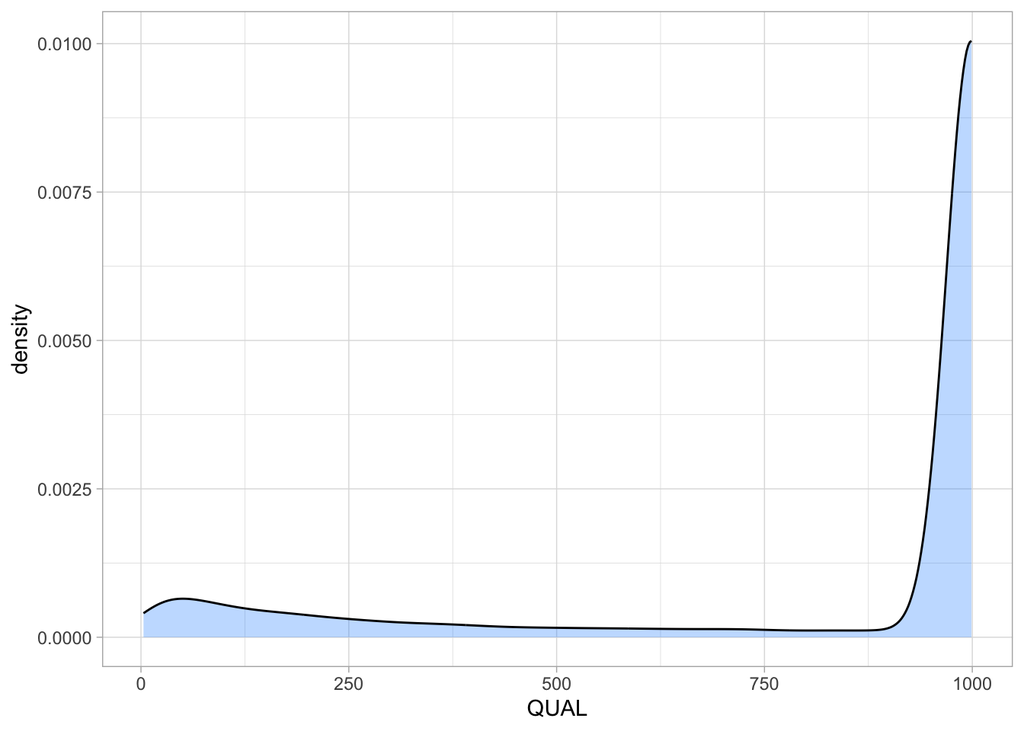

```r
heth.miss <- read.table("~/Documents/clim_morph_HETH/HETH.4assign.miss.imiss", header = TRUE)
heth.af <- read_delim("~/Documents/clim_morph_HETH/HETH.4assign.af.frq", delim = "\t",
                       col_names = c("chr", "pos", "nalleles", "nchr", "a1", "a2"), skip = 1)
heth.q <- read.table("~/Documents/clim_morph_HETH/HETH.4assign.siteQ.lqual", header=TRUE)

# plot qual
qual.p <- ggplot(heth.q, aes(QUAL)) + geom_density(fill = "dodgerblue1", colour = "black", alpha = 0.3)
qual.p + theme_light()
```

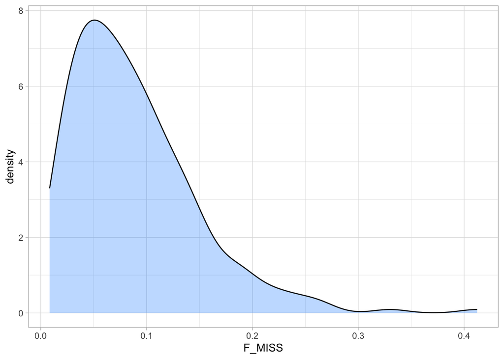

```r
# good qual, set qual filter to 30

# plot missingness
miss.p <- ggplot(heth.miss, aes(F_MISS)) + geom_density(fill = "dodgerblue1", colour = "black", alpha = 0.3)
miss.p + theme_light()
```

```r
summary(heth.miss$F_MISS)
```

```
##     Min.  1st Qu.   Median     Mean  3rd Qu.     Max.
## 0.008372 0.044336 0.075718 0.087740 0.118312 0.412309
```

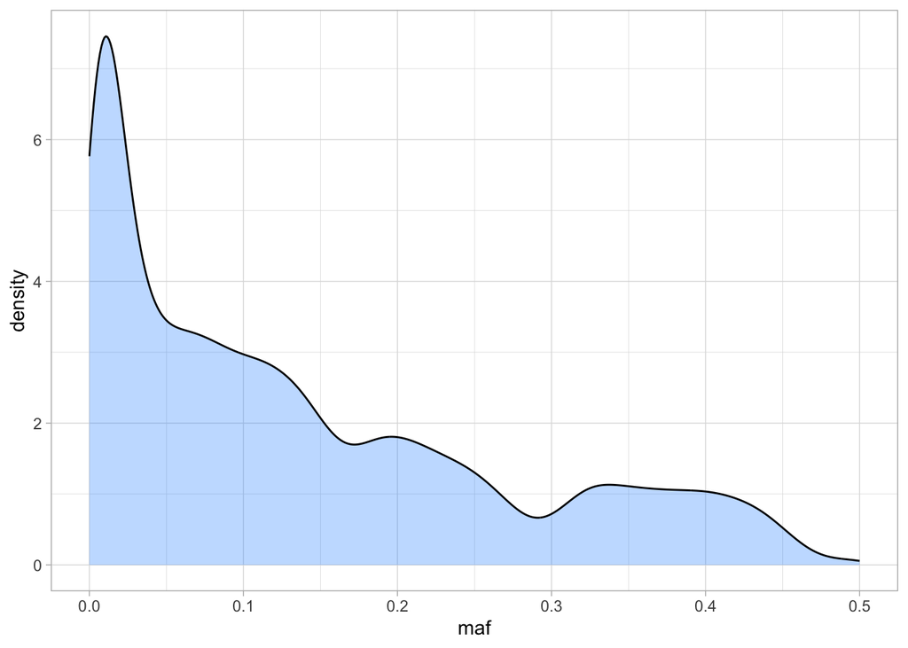

```r
# fairly high missingness overall

# find minor allele frequency
heth.af$maf <- heth.af %>% select(a1, a2) %>% apply(1, function(z) min(z))
af.p <- ggplot(heth.af, aes(maf)) + geom_density(fill = "dodgerblue1", colour = "black", alpha = 0.3)
af.p + theme_light()
```

```r
summary(heth.af$maf)
```

```
##    Min. 1st Qu.  Median    Mean 3rd Qu.    Max.
##  0.0000  0.0259  0.1008  0.1388  0.2174  0.5000
```

```r
# maybe set a higher maf filter like 0.05?
```

## Filter VCF

```bash
#!/bin/bash
#SBATCH --job-name=filtVCF
#SBATCH --output=filtVCF.%j.out
#SBATCH --error=filtVCF.%j.err
#SBATCH -t 24:00:00
#SBATCH -p RM-shared
##SBATCH -N 1
##SBATCH --ntasks-per-node 24
##SBATCH --mem=128G
#SBATCH -A
#SBATCH --mail-type=END
#SBATCH  --mail-user=

set -x


#cd /ocean/projects/deb200006p/adamsne2/HETH/vcfs/

#module load bcftools/1.10.2
module load vcftools/0.1.16

REFERENCE="/ocean/projects/deb200006p/adamsne2/HETH/reference/HETH.rmcont.assembly.fasta"
SITES="/ocean/projects/deb200006p/adamsne2/HETH/reference/HETH.all.clean.hethv0.rm_hets.rmrel.rmcont_rmscaf.pos"
VCF="/ocean/projects/deb200006p/adamsne2/HETH/vcfs/HETH.4assign.vcf.gz"

# try filtering with vcftools
vcftools --gzvcf $VCF --remove-indels --maf 0.05 --max-missing 0.9 --minQ 30 --minDP 3 --maxDP 50 --recode --stdout | ~/programs/ngsTools/htslib/bgzip -c > HETH.4assign.flt.vcf.gz
```

### PCA using SNPRelate of filtered HETH (this study and Teresa’s) VCF

N=271, SNPs=36550

```r
library(SNPRelate)

vcf.flt.fn <- "/Users/neasci/Documents/clim_morph_HETH/HETH.4assign.flt.vcf.gz"
snpgdsVCF2GDS(vcf.flt.fn, "heth.flt.gds", method="biallelic.only")
```

```
## Start file conversion from VCF to SNP GDS ...
## Method: extracting biallelic SNPs
## Number of samples: 271
## Parsing "/Users/neasci/Documents/clim_morph_HETH/HETH.4assign.flt.vcf.gz" ...
##  import 36550 variants.
## + genotype   { Bit2 271x36550, 2.4M } *
## Optimize the access efficiency ...
## Clean up the fragments of GDS file:
##     open the file 'heth.flt.gds' (2.5M)
##     # of fragments: 49
##     save to 'heth.flt.gds.tmp'
##     rename 'heth.flt.gds.tmp' (2.5M, reduced: 348B)
##     # of fragments: 20
```

```r
genofile.flt <- snpgdsOpen("heth.flt.gds")

# LD
set.seed(1000)
snpset.flt <- snpgdsLDpruning(genofile.flt, ld.threshold=0.2, verbose=F)

# Get all selected snp id
snpset.id.flt <- unlist(unname(snpset.flt))

# Get sample id
sample.id.flt <- read.gdsn(index.gdsn(genofile.flt, "sample.id"))

# PCA
pca.flt <- snpgdsPCA(genofile.flt, autosome.only = FALSE, snp.id=snpset.id.flt, num.thread=2)
```

```
## Principal Component Analysis (PCA) on genotypes:
## Excluding 0 SNP (monomorphic: TRUE, MAF: NaN, missing rate: NaN)
##     # of samples: 271
##     # of SNPs: 6,972
##     using 2 threads
##     # of principal components: 32
## PCA:    the sum of all selected genotypes (0,1,2) = 2592527
## CPU capabilities: Double-Precision SSE2
## Wed Aug  7 10:55:21 2024    (internal increment: 1796)
## [..................................................]  0%, ETC: ---        [==================================================] 100%, completed, 0s
## Wed Aug  7 10:55:21 2024    Begin (eigenvalues and eigenvectors)
## Wed Aug  7 10:55:22 2024    Done.
```

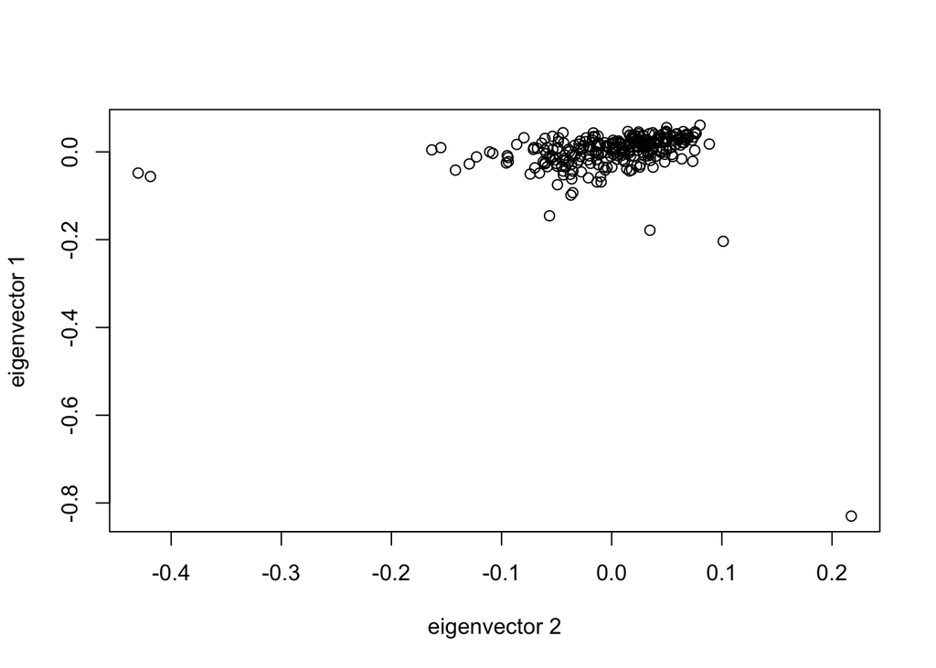

```r
#calculate the percent of variation is accounted for by the top principal components
pc.percent.flt <- pca.flt$varprop*100
#head(round(pc.percent.flt, 2))

# make a data.frame
tab.flt <- data.frame(sample.id = pca.flt$sample.id,
    EV1 = pca.flt$eigenvect[,1],    # the first eigenvector
    EV2 = pca.flt$eigenvect[,2],    # the second eigenvector
    stringsAsFactors = FALSE)
#head(tab.flt)

plot(tab.flt$EV2, tab.flt$EV1, xlab="eigenvector 2", ylab="eigenvector 1")
```

```r
showfile.gds(closeall=TRUE)  ## TO CLOSE GDS!!!
```

```
##                                               FileName ReadOnly  State
## 1 /Users/neasci/Documents/clim_morph_HETH/heth.flt.gds     TRUE closed
```

# Combine this study and Teresa’s vcf with RADseq vcf

(~/scripts/mergeVcfs.sbatch)

```bash
#!/bin/bash
#SBATCH --job-name=mergeVcfs
#SBATCH --output=mergeVcfs.%j.out
#SBATCH --error=mergeVcfs.%j.err
#SBATCH -t 12:00:00
#SBATCH -p RM-shared
##SBATCH -N 1
##SBATCH --ntasks-per-node 24
##SBATCH --mem=128G
#SBATCH -A
#SBATCH --mail-type=END
#SBATCH  --mail-user=

set -x


#cd /ocean/projects/deb200006p/adamsne2/HETH/vcfs/

module load bcftools/1.10.2
module load vcftools/

REFERENCE="/ocean/projects/deb200006p/adamsne2/HETH/reference/HETH.rmcont.assembly.fasta"
REFDIR="/ocean/projects/deb200006p/adamsne2/HETH/reference"

# merge VCFs
#bcftools merge "$REFDIR"/HETH.all.clean.hethv0.rm_hets.rmrel.rmcont.vcf.gz HETH.4assign.flt.vcf.gz -O z -o  HETHyRAD.vcf.gz

# merge VCFs
SITESDIR="/ocean/projects/deb200006p/adamsne2/HETH/vcfs"
bcftools merge "$REFDIR"/HETH.all.clean.hethv0.rm_hets.rmrel.rmcont_rmscaf.srt.vcf.gz HETH.4assign.flt.srt.vcf.gz -R "$SITESDIR"/vcfIntersec/0002.vcf -O z -o HETHyRAD.vcf.gz
```

## Combine metadata for this study + Teresa’s HETH + RAD samples

```r
#rad.samp <- as.data.frame(sample.id.merg[1:178])
#colnames(rad.samp) <- "Sample"
#rad.samp$Population <- "rad"

rad.meta <- read_excel("~/Documents/clim_morph_HETH/Allisons_HETH_master.xlsx", sheet = "Library_master")
rad.meta$Population <- rad.meta$State
rad.meta$Sample <- paste(rad.meta$Field_Number, rad.meta$Field_Number, sep = "_")
rad.samp <- read.csv("~/Documents/clim_morph_HETH/RADseqSamples.csv", header = FALSE)
rad.meta <- rad.meta %>% filter(Sample %in% as.character(rad.samp[,1]))

heth.rad <- full_join(heth.all.rm %>% select(-Month), rad.meta %>% select(-Month))

# add Genoscape breeding pop assignments for RADseq samples
breed <- read.delim("~/Documents/clim_morph_HETH/HETH.breeding.meta.rad_fluidigm.final_fixed2.txt")
```

## PCA using SNPRelate on this study and Teresa’s and RADseq merged SNPs

N=449, SNPs=29506

```r
library(SNPRelate)
library(SeqArray)
library(RColorBrewer)

vcf.merg.fn <- "/Users/neasci/Documents/clim_morph_HETH/HETHyRAD.vcf.gz"
snpgdsVCF2GDS(vcf.merg.fn, "heth.merg.gds", method="biallelic.only")
```

```
## Start file conversion from VCF to SNP GDS ...
## Method: extracting biallelic SNPs
## Number of samples: 449
## Parsing "/Users/neasci/Documents/clim_morph_HETH/HETHyRAD.vcf.gz" ...
##  import 29506 variants.
## + genotype   { Bit2 449x29506, 3.2M } *
## Optimize the access efficiency ...
## Clean up the fragments of GDS file:
##     open the file 'heth.merg.gds' (3.2M)
##     # of fragments: 47
##     save to 'heth.merg.gds.tmp'
##     rename 'heth.merg.gds.tmp' (3.2M, reduced: 324B)
##     # of fragments: 20
```

```r
genofile.merg <- snpgdsOpen("heth.merg.gds") #N=449


# Get sample id
sample.id.merg <- read.gdsn(index.gdsn(genofile.merg, "sample.id"))

# PCA
pca.merg <- snpgdsPCA(genofile.merg, autosome.only = FALSE, num.thread=2) #snp.id=snpset.id.merg
```

```
## Principal Component Analysis (PCA) on genotypes:
## Excluding 0 SNP (monomorphic: TRUE, MAF: NaN, missing rate: NaN)
##     # of samples: 449
##     # of SNPs: 29,506
##     using 2 threads
##     # of principal components: 32
## PCA:    the sum of all selected genotypes (0,1,2) = 20201828
## CPU capabilities: Double-Precision SSE2
## Wed Aug  7 10:55:28 2024    (internal increment: 1084)
## [..................................................]  0%, ETC: ---        [==================================================] 100%, completed, 1s
## Wed Aug  7 10:55:29 2024    Begin (eigenvalues and eigenvectors)
## Wed Aug  7 10:55:29 2024    Done.
```

```r
# calculate the percent of variation is accounted for by the top principal components
pc.percent.merg <- pca.merg$varprop*100
head(round(pc.percent.merg, 2))
```

```
## [1] 5.60 1.00 0.59 0.48 0.34 0.34
```

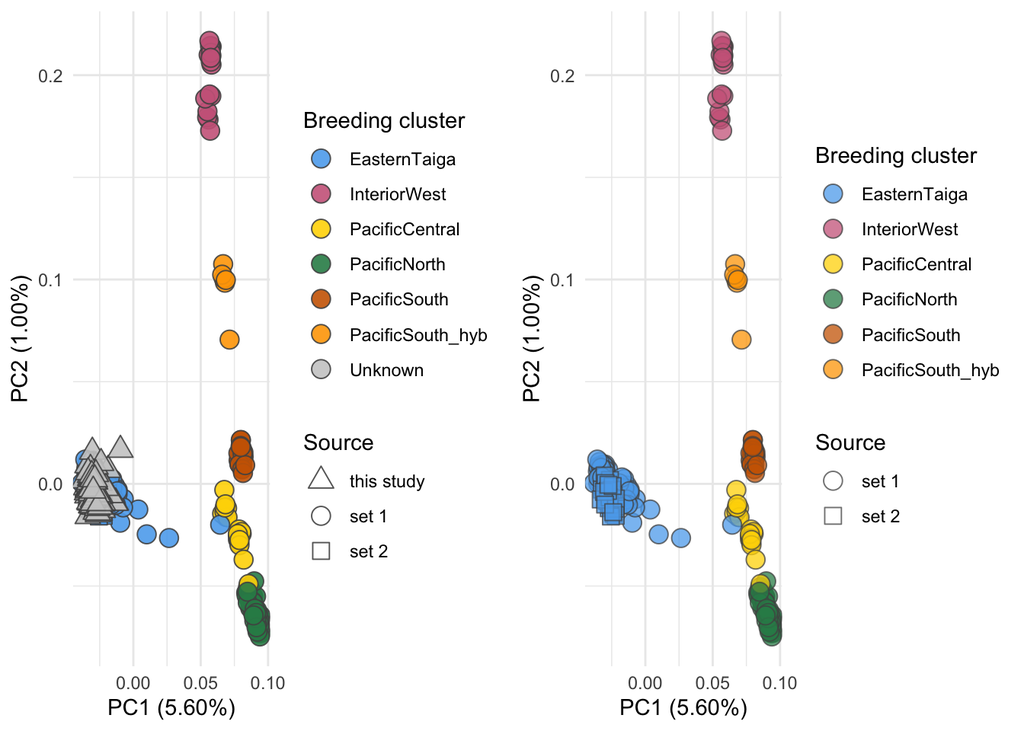

```r
# make a data.frame
tab.merge <- data.frame(sample.id = pca.merg$sample.id,
    EV1 = pca.merg$eigenvect[,1],    # the first eigenvector
    EV2 = pca.merg$eigenvect[,2],    # the second eigenvector
    stringsAsFactors = FALSE)
#head(tab.merge)

# Get population information
# the order of sample IDs as the same as population codes
heth.rad <- heth.rad %>% arrange(Sample)

#head(cbind(sample.id.merg, heth.rad$Population))

tab.merge2 <- data.frame(sample.id = pca.merg$sample.id,
    Population = factor(heth.rad$Population)[match(pca.merg$sample.id, sample.id.merg)],
    EV1 = pca.merg$eigenvect[,1],    # the first eigenvector
    EV2 = pca.merg$eigenvect[,2],    # the second eigenvector
    stringsAsFactors = FALSE)
#head(tab.merge2)


tab.merge2$Source <- ifelse(tab.merge2$Population == "IL", "this study", "foo") #UCD
tab.merge2$Source <- ifelse(tab.merge2$Population == "AB"| tab.merge2$Population == "CN" | tab.merge2$Population == "MB", "set 2", tab.merge2$Source) #teresa
tab.merge2$Source <- ifelse(tab.merge2$Population == "AK"| tab.merge2$Population == "AZ" | tab.merge2$Population == "BC" |tab.merge2$Population == "CA"| tab.merge2$Population == "ME" | tab.merge2$Population == "NM"|tab.merge2$Population == "PA"| tab.merge2$Population == "UT", "set 1", tab.merge2$Source) #rad

#tab.merge2$Population <- factor(tab.merge2$Population, levels = c("AK", "BC", "AB", "MB", "CN", "IL", "PA", "ME", "CA", "UT", "AZ", "NM"))

lbls <- paste("PC", 1:4, " (", format(pc.percent.merg[1:4], digits=2), "%)", sep="")
#pairs(pca.merg$eigenvect[,1:4], col=tab.merge2$Population, labels=lbls)

# remove bad samples - Z438055
tab.merge2 <- tab.merge2 %>% filter(!sample.id == "Z438055")

hybs <- c("2311-00944", "2311-01919", "2341-14499", "2341-14902", "2341-15638", "2591-00133")
tab.merge3a <- tab.merge2 %>% mutate(Sample=sample.id) %>% separate(Sample, into = c("Sample", "nada"), sep = "_") %>% dplyr::select(-nada)
tab.merge3 <- left_join(tab.merge3a, breed)
tab.merge3$Genetic.Cluster <- ifelse(grepl("^AB", tab.merge3$Sample), "EasternTaiga", tab.merge3$Genetic.Cluster)
tab.merge3$Genetic.Cluster <- ifelse(grepl("^MB", tab.merge3$Sample), "EasternTaiga", tab.merge3$Genetic.Cluster)
tab.merge3$Genetic.Cluster <- ifelse(grepl("^MN", tab.merge3$Sample), "EasternTaiga", tab.merge3$Genetic.Cluster)
tab.merge3$Genetic.Cluster <- ifelse(grepl("^UP", tab.merge3$Sample), "EasternTaiga", tab.merge3$Genetic.Cluster)
tab.merge3$Genetic.Cluster <- ifelse(grepl("^C7", tab.merge3$Sample), "EasternTaiga", tab.merge3$Genetic.Cluster)
tab.merge3$Genetic.Cluster <- ifelse(tab.merge3$Sample == "2341-13975", "EasternTaiga", tab.merge3$Genetic.Cluster)
tab.merge3$Genetic.Cluster <- ifelse(tab.merge3$Sample == "2551-80770", "PacificSouth", tab.merge3$Genetic.Cluster)
tab.merge3$Genetic.Cluster <- ifelse(tab.merge3$Sample == "2551-80774", "PacificSouth", tab.merge3$Genetic.Cluster)
tab.merge3$Genetic.Cluster <- ifelse(tab.merge3$Sample == "2551-80771", "PacificSouth", tab.merge3$Genetic.Cluster)
tab.merge3$Genetic.Cluster <- ifelse(tab.merge3$Sample %in% hybs, "PacificSouth_hyb", tab.merge3$Genetic.Cluster)
tab.merge3$Genetic.Cluster <- ifelse(tab.merge3$Source == "this study", "Unknown", tab.merge3$Genetic.Cluster)
tab.merge3$Genetic.Cluster <- ifelse(tab.merge3$Sample %in% c("Z332011", "Z332018"), "Unknown", tab.merge3$Genetic.Cluster)
tab.merge3$Population <- ifelse(tab.merge3$Sample %in% c("Z332011", "Z332018"), "IL", tab.merge3$Population)
tab.merge3$Source <- ifelse(tab.merge3$Sample %in% c("Z332011", "Z332018"), "this study", tab.merge3$Source)

tab.merge3$Source <- factor(tab.merge3$Source, levels = c("this study", "set 1", "set 2"))


cluster_cols4pca <-  gscols <- c(EasternTaiga = "steelblue2", InteriorWest = "palevioletred3", PacificCentral = "gold", PacificNorth = "seagreen", PacificSouth = "darkorange3", PacificSouth_hyb = "orange", Unknown = "gray80")


cluster.pca <- ggplot(tab.merge3, aes(x=EV1, y=EV2, fill=Genetic.Cluster, shape=Source)) +
  geom_point(size=4, alpha=0.90, color="gray32") +
  #geom_text(label=tab.merge2$sample.id) + # to ID sample in the middle
  xlab(lbls[1]) + ylab(lbls[2]) +
  scale_fill_manual(values = cluster_cols4pca) +
  scale_shape_manual(values=c(24, 21, 22)) +
  guides(fill = guide_legend(override.aes = list(shape = c(21)), title = "Breeding cluster")) +
  theme_minimal()

cluster.noChi <- ggplot(tab.merge3 %>% filter(!Source == "this study"), aes(x=EV1, y=EV2, fill=Genetic.Cluster, shape=Source)) +
  geom_point(size=4, alpha=0.75, color="gray32") +
  #geom_text(label=tab.merge2$sample.id) + # to ID sample in the middle
  xlab(lbls[1]) + ylab(lbls[2]) +
  scale_fill_manual(values = cluster_cols4pca) +
  scale_shape_manual(values=c(21, 22)) +
  guides(fill = guide_legend(override.aes = list(shape = c(21)), title = "Breeding cluster")) +
  theme_minimal()


ggpubr::ggarrange(cluster.pca, cluster.noChi)
```

# Use assignPop to identify breeding population this study’s samples come from

## Set up files - known breeding population samples - Teresa’s and RADseq samples

```r
library(readxl)
library(vcfR)
library(adegenet)
library(hierfstat)


# baseline data collected from source population (RADseq breeding pop assigned to clusters, and Teresa's)
hethyrad.vcf <- read.vcfR("/Users/neasci/Documents/clim_morph_HETH/HETHyRAD.vcf.gz")
```

```
## Scanning file to determine attributes.
## File attributes:
##   meta lines: 4653
##   header_line: 4654
##   variant count: 29506
##   column count: 458
## Meta line 1000 read in.Meta line 2000 read in.Meta line 3000 read in.Meta line 4000 read in.Meta line 4653 read in.
## All meta lines processed.
## gt matrix initialized.
## Character matrix gt created.
##   Character matrix gt rows: 29506
##   Character matrix gt cols: 458
##   skip: 0
##   nrows: 29506
##   row_num: 0
## Processed variant 1000Processed variant 2000Processed variant 3000Processed variant 4000Processed variant 5000Processed variant 6000Processed variant 7000Processed variant 8000Processed variant 9000Processed variant 10000Processed variant 11000Processed variant 12000Processed variant 13000Process…
## All variants processed
```

```r
hethyrad.genind <- vcfR2genind(hethyrad.vcf) ## Create genind object

# get pop names
hethyrad.pops <- hethyrad.genind@tab[,1] %>%
  names() %>%
  as_tibble %>%
  separate(value, into = c("Sample", "stuff"), sep = "_") %>% dplyr::select(-stuff)

# define studies and subset to just RADseq and Teresa's samples
hethyrad.pops$Pop <- ifelse(grepl("^Z", hethyrad.pops$Sample), "thisStudy", "RADseq")
hethyrad.pops$Pop <- ifelse(grepl("^AB", hethyrad.pops$Sample), "AB", hethyrad.pops$Pop)
hethyrad.pops$Pop <- ifelse(grepl("^MB", hethyrad.pops$Sample), "MB", hethyrad.pops$Pop)
hethyrad.pops$Pop <- ifelse(grepl("^MN", hethyrad.pops$Sample), "CN", hethyrad.pops$Pop)
hethyrad.pops$Pop <- ifelse(grepl("^UP", hethyrad.pops$Sample), "CN", hethyrad.pops$Pop)
hethyrad.pops <- hethyrad.pops %>% mutate(Pop = as.factor(Pop))

hethyrad.genind@pop <- hethyrad.pops$Pop

rad.genind <- poppr::popsub(hethyrad.genind, exclude=c("thisStudy")) # 214 individuals; 29,506 loci

# define genetic clusters - using breed from CH and assigning all of Teresa's to EasternTaiga
rad.popsA <- rad.genind@tab[,1] %>%
  names() %>%
  as_tibble %>%
  separate(value, into = c("Sample", "stuff"), sep = "_") %>% dplyr::select(-stuff)

rad.pops <- full_join(rad.popsA, breed)
rad.pops$Genetic.Cluster <- ifelse(grepl("^AB", rad.pops$Sample), "EasternTaiga", rad.pops$Genetic.Cluster)
rad.pops$Genetic.Cluster <- ifelse(grepl("^MB", rad.pops$Sample), "EasternTaiga", rad.pops$Genetic.Cluster)
rad.pops$Genetic.Cluster <- ifelse(grepl("^MN", rad.pops$Sample), "EasternTaiga", rad.pops$Genetic.Cluster)
rad.pops$Genetic.Cluster <- ifelse(grepl("^UP", rad.pops$Sample), "EasternTaiga", rad.pops$Genetic.Cluster)
rad.pops$Genetic.Cluster <- ifelse(grepl("^C7", rad.pops$Sample), "EasternTaiga", rad.pops$Genetic.Cluster)

# find samples still missing genetic cluster info, and add based on lat/long and genoscape
missSamps1 <- rad.pops %>% filter(is.na(Genetic.Cluster))
# add allisons meta data
meta.a <- read_xlsx("~/Documents/clim_morph_HETH/Allisons_HETH_master.xlsx", sheet = "Library_master")
meta.a$Sample <- meta.a$Field_Number
missSamps1.a <- meta.a %>% filter(Sample %in% missSamps1$Sample)
rad.pops$Genetic.Cluster <- ifelse(rad.pops$Sample == "2341-13975", "EasternTaiga", rad.pops$Genetic.Cluster)
rad.pops$Genetic.Cluster <- ifelse(rad.pops$Sample == "2551-80770", "PacificSouth", rad.pops$Genetic.Cluster)
rad.pops$Genetic.Cluster <- ifelse(rad.pops$Sample == "2551-80774", "PacificSouth", rad.pops$Genetic.Cluster)
rad.pops$Genetic.Cluster <- ifelse(rad.pops$Sample == "2551-80771", "PacificSouth", rad.pops$Genetic.Cluster)

# remove samples that were in CH breed data but not in the rad genetic data, and remove any duplicates
missSamps2 <- setdiff(rad.pops$Sample, rad.popsA$Sample)
rad.pops <- rad.pops %>% filter(!Sample %in% missSamps2) #N=215
rad.pops <- rad.pops[!duplicated(rad.pops$Sample), ] #N=214

# assign genid pops as genetic clusters
rad.pops <- rad.pops %>% mutate(Genetic.Cluster = as.factor(Genetic.Cluster))
rad.genind@pop <- rad.pops$Genetic.Cluster
strata(rad.genind) <- as.data.frame(rad.pops$Genetic.Cluster)


# save genind obj to convert to genepop format for assignPop - using writeGenPop.R from https://github.com/romunov/zvau/blob/master/R/writeGenPop.R

source("~/Documents/clim_morph_HETH/popAssignment/writeGenPop.R")

#writeGenPop(rad.genind, "~/Documents/clim_morph_HETH/popAssignment/rad.genepop.txt", comment = "Allison's RAD and Teresa's data")
```

## Set up files - UNknown samples - this study

```r
#### get just my samples VCF to run the unknowns - make genepop
bay.genind <- poppr::popsub(hethyrad.genind, exclude=c("AB", "CN", "MB", "RADseq")) # 235 individuals; 29,506 loci
#save(bay.genind, file="~/Documents/clim_morph_HETH/popAssignment/bay.genind.RData")

source("~/Documents/clim_morph_HETH/popAssignment/writeGenPop.R")

#writeGenPop(bay.genind, "~/Documents/clim_morph_HETH/popAssignment/bay.genepop.txt", comment = "Bay's HETH data to assign")
```

## Run assignPOP

```r
library(assignPOP)
library(klaR)

# Read in known data (Teresa's and RADseq)
rad.gpopy <- read.Genepop("~/Documents/clim_morph_HETH/popAssignment/rad.genepop.txt", haploid=FALSE, pop.names = c("EasternTaiga", "InteriorWest", "PacificCentral", "PacificNorth", "PacificSouth", "PacificSouth_hyb"))

# Read in unknown data (this study)
bay.gpop <- read.Genepop("~/Documents/clim_morph_HETH/popAssignment/bay.genepop.txt", haploid = FALSE, pop.names=c("thisStudy"))


# perform assignment test with 3 different models
assign.X(rad.gpop, bay.gpop, model="randomForest", dir = "~/Documents/NicoleAdams/assignPop3_assign_RF/")
assign.X(rad.gpop, bay.gpop, model="naiveBayes", dir = "~/Documents/NicoleAdams/assignPop3_assign_Bayes/")
assign.X(rad.gpop, bay.gpop, model="svm", dir = "~/Documents/NicoleAdams/assignPop3_assign_svm/")
```

### Plot assignPop results

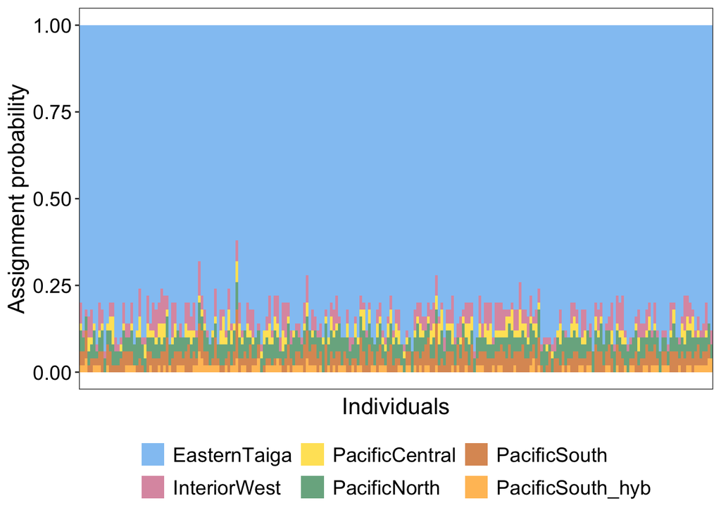

```r
# Read in assignPop results and make plot
rf <- read.table("~/Documents/clim_morph_HETH/popAssignment/assignPop3_assign_RF/AssignmentResult_RF.txt", header = T)

# melt
ndf <- melt(rf, id.vars=c("Ind.ID","pred.pop"))

# match colors to genoscape map
gscols <- c("steelblue2", "palevioletred3", "gold", "seagreen", "darkorange3", "orange")
#scales::show_col(gscols)
popCols <- c("EasternTaiga" = gscols[1], "InteriorWest" = gscols[2], "PacificCentral" = gscols[3], "PacificNorth" = gscols[4], "PacificSouth" = gscols[5], "PacificSouth_hyb" = gscols[6])


stackplot <- ggplot(ndf, aes(x=Ind.ID, y=value, fill=variable))+
        geom_bar(stat="identity", width=1, alpha=0.7)+ # width=1 allows no space between bars
        scale_fill_manual(values = popCols)+ # Make the bar color in grey scale
        ylab("Assignment probability")+
        xlab("Individuals")+
        guides(fill=guide_legend(title=NULL, position = "bottom"))+ #Hiding title of legend
        theme_bw()+
        theme(panel.grid.major = element_blank(), panel.grid.minor=element_blank(),#hiding grid of the panel
              strip.background = element_rect(colour="black", fill="white", linetype="solid"),#change facet title background color
              plot.title = element_text(size=16, vjust=0.8),
              legend.text = element_text(size=14),
              strip.text.x = element_text(size=16),
              axis.title.y = element_text(size=16), axis.text.y = element_text(size=14, colour="black"),
              axis.title.x = element_text(size=16), axis.text.x = element_blank(),
              axis.ticks.x=element_blank())

stackplot
```

Map of our samples + teresas + radSeq WITH SHAPEFILE of GENOSCAPE groups Following https://github.com/cbossu/BGP_GenomicsPipeline/blob/main/7.Make-a-BGP-map-COYE.wWint.Rmd

```r
# install packages
#remotes::install_github("eriqande/TESS3_encho_sen")  # for special version of tess3r
#remotes::install_github("eriqande/genoscapeRtools")  # for Eric's genoscapeRtools

library(raster)  # important to load before tidyverse, otherwise it masks select()
library(tidyverse)
library(downloader) # to DL natural earth data
library(rnaturalearth)
library(rnaturalearthdata)
library(terra)
library(tidyterra)
```

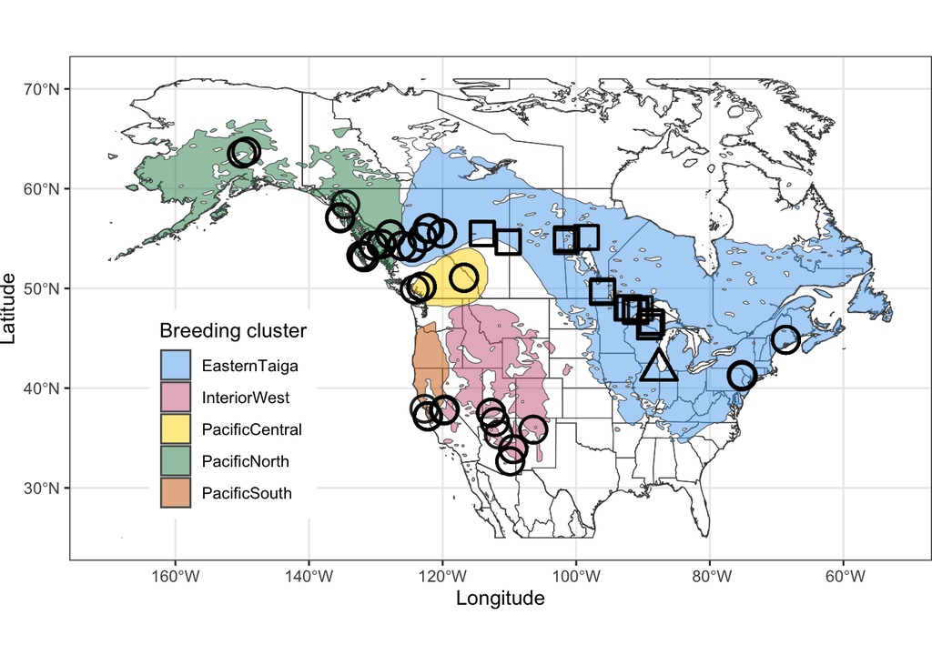

```r
library(ggplot2)
library(sf)
cluster_colors <-  gscols <- c(EasternTaiga = "steelblue2", InteriorWest = "palevioletred3", PacificCentral = "gold", PacificNorth = "seagreen", PacificSouth = "darkorange3", PacificSouthHyb = "orange")

#scales::show_col(cluster_colors)

heth_sh1 <- st_read("~/Documents/clim_morph_HETH/HETH_shapefiles/HETH.genoscape_brick.WGS84_1.5no_ovlp2.shp") # Interior West
heth_sh2 <- st_read("~/Documents/clim_morph_HETH/HETH_shapefiles/HETH.genoscape_brick.WGS84_2.5no_ovlp2.shp") # Pacific North
heth_sh3 <- st_read("~/Documents/clim_morph_HETH/HETH_shapefiles/HETH.genoscape_brick.WGS84_3.5no_ovlp2.shp") # Eastern Taiga
heth_sh4 <- st_read("~/Documents/clim_morph_HETH/HETH_shapefiles/HETH.genoscape_brick.WGS84_4.5no_ovlp2.shp") # Pacific South
heth_sh5 <- st_read("~/Documents/clim_morph_HETH/HETH_shapefiles/HETH.genoscape_brick.WGS84_5.5no_ovlp2.shp") # Pacific Central
# convert sf objs to spatVectors for terra
heth_sh1_vect <- vect(heth_sh1)
heth_sh2_vect <- vect(heth_sh2)
heth_sh3_vect <- vect(heth_sh3)
heth_sh4_vect <- vect(heth_sh4)
heth_sh5_vect <- vect(heth_sh5)

# Define the domain for cropping
xmin <- -170
xmax <- -45
ymin <- 25
ymax <- 71

# Get coastline and crop
coast <- ne_coastline(returnclass = "sf")
coast <- vect(coast)  # Convert to terra's SpatVector
coast_cropped <- crop(coast, ext(xmin, xmax, ymin, ymax))

# Get countries and crop
country <- ne_countries(country = c("United States of America", "Mexico", "Canada"), returnclass = "sf")
country <- vect(country)  # Convert to terra's SpatVector
country_cropped <- crop(country, ext(xmin, xmax, ymin, ymax))

# Get states and crop
states <- ne_states(country = c("United States of America", "Mexico", "Canada"), returnclass = "sf")
states <- vect(states)  # Convert to terra's SpatVector
states_cropped <- crop(states, ext(xmin, xmax, ymin, ymax))

heth.rad$Source <- ifelse(heth.rad$Population == "IL", "this study", "foo") #UCD
heth.rad$Source <- ifelse(heth.rad$Population == "AB"| heth.rad$Population == "CN" | heth.rad$Population == "MB", "set 2", heth.rad$Source) #teresa
heth.rad$Source <- ifelse(heth.rad$Population == "AK"| heth.rad$Population == "AZ" | heth.rad$Population == "BC" |heth.rad$Population == "CA"| heth.rad$Population == "ME" | heth.rad$Population == "NM"|heth.rad$Population == "PA"| heth.rad$Population == "UT", "set 1", heth.rad$Source) #rad
heth.rad$Source <- factor(heth.rad$Source, levels = c("this study", "set 1", "set 2"))

heth.gsp3 <- ggplot() +
  #geom_spatvector(data = coast_cropped) +
  geom_spatvector(data = country_cropped, color = "gray25", fill = NA) +
  geom_spatvector(data = states_cropped, color = "gray25", fill = NA) +
  # Assume heth_sh* are SpatVector objects
  geom_spatvector(data = heth_sh1_vect, aes(fill = "InteriorWest"), alpha = 0.5) +
  geom_spatvector(data = heth_sh2_vect, aes(fill = "PacificNorth"), alpha = 0.5) +
  geom_spatvector(data = heth_sh3_vect, aes(fill = "EasternTaiga"), alpha = 0.5) +
  geom_spatvector(data = heth_sh4_vect, aes(fill = "PacificSouth"), alpha = 0.5) +
  geom_spatvector(data = heth_sh5_vect, aes(fill = "PacificCentral"), alpha = 0.5) +
  geom_point(data = heth.rad, mapping = aes(x = Long, y = Lat, shape = Source), size = 6, stroke=1.2, alpha = 0.88, inherit.aes = FALSE, show.legend = FALSE) +
  scale_fill_manual(values = cluster_colors) +
  scale_shape_manual(values = c(24, 21, 22)) +
  xlab("Longitude") + ylab("Latitude") +
  guides(fill = guide_legend(override.aes = list(shape = c(21)), title = "Breeding cluster")) +
  theme_bw() +
  theme(legend.position = c(0.19, 0.29), plot.margin = unit(c(0, 0, 0, 0), "inches")) +
  coord_sf()
#ggsave2(plot = heth.gsp3, filename = "~/Documents/clim_morph_HETH/HETH-teresa-rad_mapwclusters_7-28-24.png", width = 12, height = 8)

heth.gsp3
```

# Figure S2 - map, PCAs, assignPop results

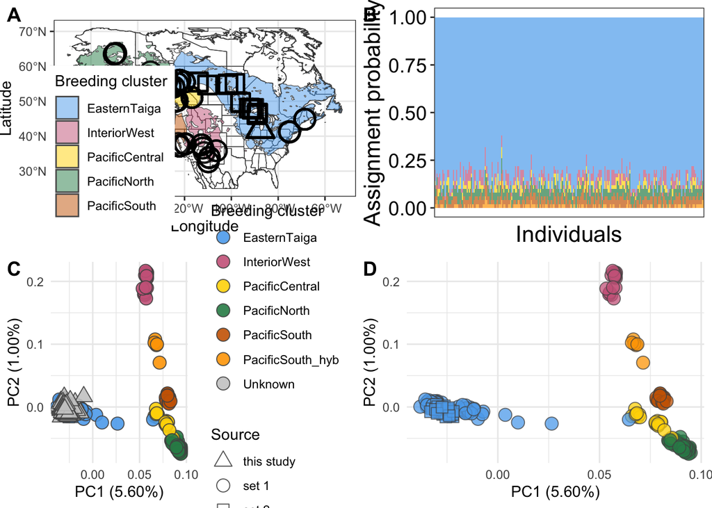

```r
row1 <- ggarrange(heth.gsp3, stackplot + theme(legend.position = "none"), labels = c("A", "B"), nrow=1)

row2 <- ggarrange(cluster.pca, cluster.noChi + theme(legend.position = "none"),  labels = c("C", "D") )

map_pcas_assign <-  ggarrange(row1, row2, ncol = 1 )

#ggsave(plot = map_pcas_assign, filename = "~/Documents/clim_morph_HETH/HETH-teresa-rad_mapYpcasYassign_7-31-24.png", width = 13, height = 10)

map_pcas_assign
```